# Statistical inference with the GSS data

## Setup

### Load packages

```r
options(warn=-1)
library(ggplot2)
library(dplyr)
library(statsr)
```

```r
load("gss.Rdata")
```

```r
shadenorm = function(below=NULL, above=NULL, pcts = c(0.025,0.975), mu=0, sig=1, numpts = 500, color = "gray", dens = 40,

                    justabove= FALSE, justbelow = FALSE, lines=FALSE,between=NULL,outside=NULL){



    if(is.null(between)){

         below = ifelse(is.null(below), qnorm(pcts[1],mu,sig), below)

         above = ifelse(is.null(above), qnorm(pcts[2],mu,sig), above)

    }



    if(is.null(outside)==FALSE){

         below = min(outside)

         above = max(outside)

    }

    lowlim = mu - 4*sig

    uplim  = mu + 4*sig



    x.grid = seq(lowlim,uplim, length= numpts)

    dens.all = dnorm(x.grid,mean=mu, sd = sig)

    if(lines==FALSE){

          plot(x.grid, dens.all, type="l", xlab="X", ylab="Density")

    }

    if(lines==TRUE){

          lines(x.grid,dens.all)

    }



    if(justabove==FALSE){

        x.below    = x.grid[x.grid<below]

        dens.below = dens.all[x.grid<below]

        polygon(c(x.below,rev(x.below)),c(rep(0,length(x.below)),rev(dens.below)),col=color,density=dens)

    }

    if(justbelow==FALSE){

        x.above    = x.grid[x.grid>above]

        dens.above = dens.all[x.grid>above]

        polygon(c(x.above,rev(x.above)),c(rep(0,length(x.above)),rev(dens.above)),col=color,density=dens)

    }



    if(is.null(between)==FALSE){

         from = min(between)

         to   = max(between)



         x.between    = x.grid[x.grid>from&x.grid<to]

         dens.between = dens.all[x.grid>from&x.grid<to]

         polygon(c(x.between,rev(x.between)),c(rep(0,length(x.between)),rev(dens.between)),col=color,density=dens)

    }



}
```

## Part 1: Data

According to the description of the methodology which was used for GSS written in [Wikipedia](https://en.wikipedia.org/wiki/General_Social_Survey#Methodology), the GSS **randomly selects** respondents across the United States using area probability design. It indicates that the conclusions derived from this dataset can be generalized to the population of the United States. This dataset, however, is an **observational** study with confounding variables, so its data cannot be use to make causal conclusions.

## Part 2: Research question

My interest is identifying how different opinions for **government responsibilites** ,specifically for social welfare, are depending on **economical class**. I chose this question because many times I have watched situations that political parties who claim that government should aid the poor are defeated by the parties who don’t -not only in the United States- because of **a lack of support of the poor** ironically. I want to clarify that the poor support the policies that improve standard of their living as expected.

## Part 3: Exploratory data analysis

Prior to analysis on my interest, We have to make data clean and classify binned income data value into some categories. We can explore income data by plotting the histogram of income06 column data, which states total family income of each respondent.

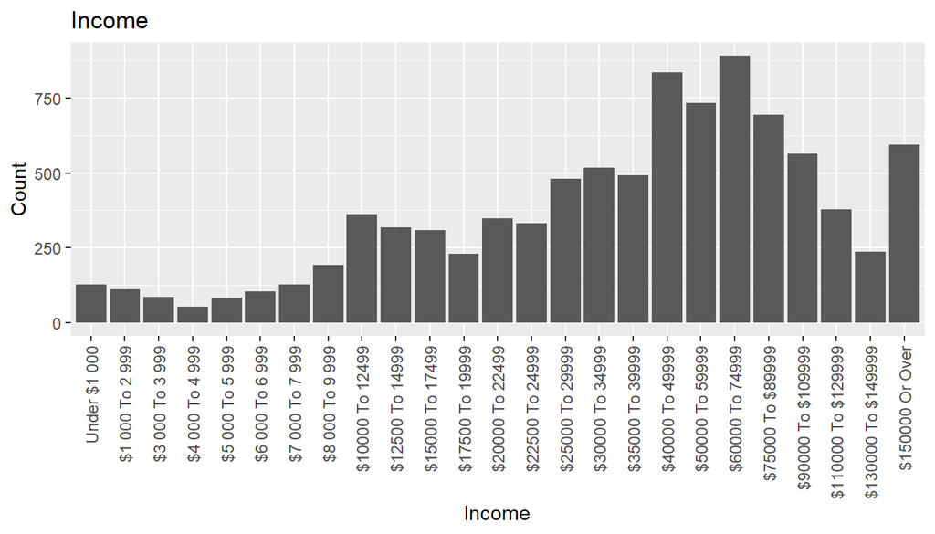

```r
ggplot(data = subset(gss, !is.na(income06) & !grepl("Refused", income06)), aes(x=income06)) + geom_histogram(stat = "count") + theme(axis.text.x = element_text(angle = 90, hjust = 1, vjust = 0.5)) + labs(title = "Income", x = "Income", y = "Count")
```

According to plot above, income distribution is left-skewed. This is because very high income bins are combined into one bin.

Though there is the column addressing subjective class responded by respondents themselves, we need to make objective one. To categorize this data into fewer categories, I used the methodology which was used by [OECD](https://www.oecd.org/statistics/Compare-your-income-methodology.pdf). I classified 50% to 150% of median of income of US people into middle class, below 50% into lower class and above 150% into upper class. Since some upper part of income data is ommited here, we use median household income for the United States in 2012 excerpted from [department of numbers](https://www.deptofnumbers.com/income/us/). Instead of using exact numbers, we utilize median of each bin as representative value because this dataset does not contain numerical value. As you see, this approach has some approximations and assumptions, so it should be interpreted carefully.

```r
intervals <- matrix(c(0, 999, 1000, 2999, 3000, 3999, 4000, 4999, 5000, 5999, 6000, 6999, 7000, 7999, 8000, 9999, 10000, 12499, 12500, 14999, 15000, 17499, 17500, 19999, 20000, 22499, 22500, 24999, 25000, 29999, 30000, 34999, 35000, 39999, 40000, 49999, 50000, 59999, 60000, 74999, 75000, 89999, 90000, 109999, 110000, 129999, 130000, 149999, 150000, 159999), ncol = 2, byrow = TRUE)
representative_values <- apply(intervals, 1, mean)
levels(gss$income06) <- c(representative_values, "Refused")
gss$income06 <- as.numeric(as.character(gss$income06))

median_income <- 54948
gss[gss$income06 < 1/2*median_income & !is.na(gss$income06),"oecdclass"] <- "lower_class"
gss[gss$income06 >= 1/2*median_income & gss$income06 <= 3/2*median_income & !is.na(gss$income06),"oecdclass"] <- "middle_class"
gss[gss$income06 > 3/2*median_income & !is.na(gss$income06),"oecdclass"] <- "upper_class"
gss$oecdclass <- factor(gss$oecdclass)

table(gss$oecdclass)
```

```
##
##  lower_class middle_class  upper_class
##         2789         3953         2468
```

Now, We have objectively classified categories of income. We can simply say that this sample has abundant respondents in middle income class. Next, we can summarize and explore the distribution of respondents’ opinions on whether goverment should help the poor.

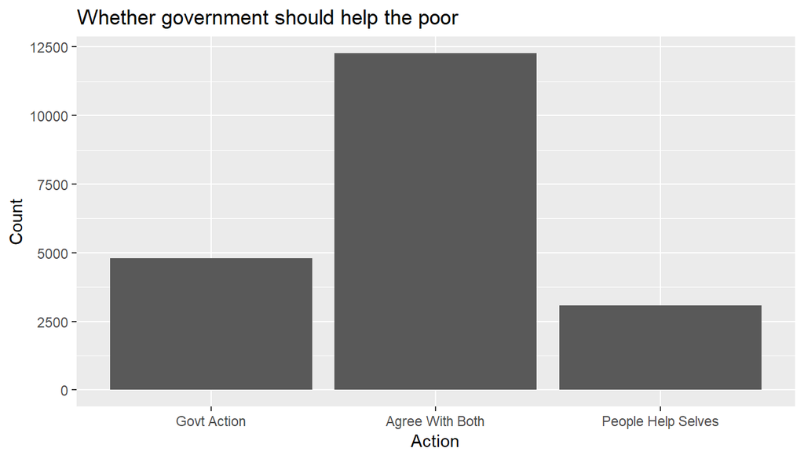

```r
ggplot(data = subset(gss, !is.na(helppoor)), aes(x=helppoor)) + geom_histogram(stat = "count") + labs(title = "Whether government should help the poor", x = "Action", y = "Count")
```

Majority of respondents agree with both government action and self-reliance. Before conducting inference, we can draw contingency table using column “oecdclass” and “helppoor”.

```r
tbl <- table(gss$helppoor, gss$oecdclass)
tbl
```

```
##
##                      lower_class middle_class upper_class
##   Govt Action                472          344         111
##   Agree With Both            691         1057         608
##   People Help Selves         139          257         186
```

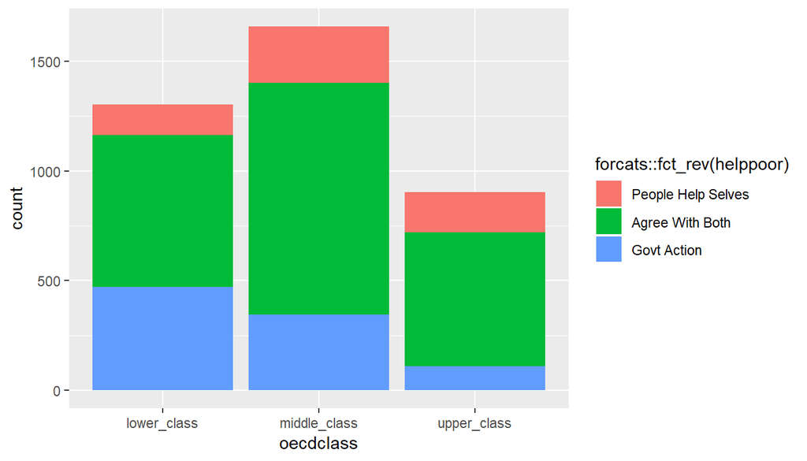

```r
tbl_df <- as.data.frame(tbl)
colnames(tbl_df) <- c("helppoor", "oecdclass", "count")
tbl_df$helppoor <- as.factor(tbl_df$helppoor)

ggplot(tbl_df, aes(x = oecdclass, y = count, fill = forcats::fct_rev(helppoor))) +
   geom_bar(stat = 'identity')
```

## Part 4: Inference

To answer our research question, we can conduct statistical inferences.

The first subject is that **there is obvious difference in proportions of US people only supporting government action between lower class and upper class**. To claim so, we will use inference on difference of two proportions because we want to compare two proportions.

$p_{L}$ is the population proportions of US people who only support government action of lower class group.

$p_{U}$ is the population proportions of US people who only support government action of upper class group.

### 1) Confidence interval

#### Check conditions

1. Independence : Each group is simple random sample from less than 10% of the population obviously so the observations are independent, both within the samples and between the samples.
2. Skewness : The success-failure conditions hold for each sample.

#### Perform inference

Because all conditions are met, the normal model can be used for the point estimate of the difference in support.

### 2) Hypothesis test

#### State Hypothesis

H<sub>0</sub> : $p_{L} = p_{U}$

H<sub>A</sub> : $p_{L} \neq p_{U}$

#### Check conditions

1. Independence : same as confidence interval
2. Skewness : To check if success-faliure conditions are met, we should use the **pooled proportion** in this case. It is our best estimate of the proportions $p_{L}$ and $p_{U}$ *if the null hypothesis is true that $p_{L} = p_{U}$*

#### Perform inference

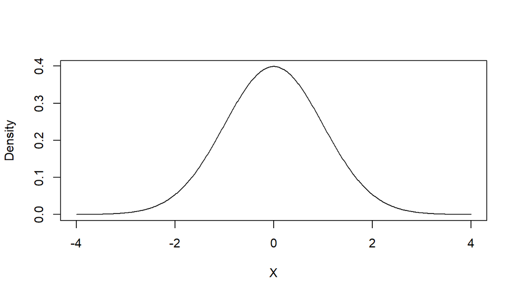

```r
shadenorm(below = -10, above = 10)
```

*shadenorm function is the customized function made by [R-blogger user](https://www.r-bloggers.com/how-to-shade-under-a-normal-density-in-r/).

Because shaded area is utmost tiny, we cannot see it.

The lower tail area is :

```r
pnorm(q = -10, lower.tail = TRUE)
```

```
## [1] 7.619853e-24
```

we double to get the p-value:

```r
pnorm(q = -10, lower.tail = TRUE) * 2
```

```
## [1] 1.523971e-23
```

The second subject is that **there is association between opinions on supporting government action to help people in poverty and income classes**. To identify this claim, we will hire chi-square test for two-way tables.

#### State Hypothesis

H<sub>0</sub> : Opinions on supporting government action to help poor people are equally distributed accross all income classes.

H<sub>A</sub> : Opinions on supporting government action to help poor people are not equally distributed accross all income classes.

The goal is to check whether *oecdclass* variable is independent of the *helppoor* variable.

We can again review the contingency table but added total row and columns at this time.

```r
addmargins(table(gss$helppoor, gss$oecdclass), FUN = list(Total = sum), quiet = TRUE)
```

```
##
##                      lower_class middle_class upper_class Total
##   Govt Action                472          344         111   927
##   Agree With Both            691         1057         608  2356
##   People Help Selves         139          257         186   582
##   Total                     1302         1658         905  3865
```

Assuming that there was no difference between the three groups, we can compute expected counts for a two-way table using the row totals, column totals, and the table total.

```r
two_way_table <- table(gss$helppoor, gss$oecdclass)
Xsq <- chisq.test(two_way_table)
addmargins(Xsq$expected, FUN = list(Total = sum), quiet = TRUE)
```

```
##
##                      lower_class middle_class upper_class Total
##   Govt Action           312.2779     397.6626    217.0595   927
##   Agree With Both       793.6642    1010.6722    551.6636  2356
##   People Help Selves    196.0580     249.6652    136.2768   582
##   Total                1302.0000    1658.0000    905.0000  3865
```

#### Check conditions

1. Independence : Each case that contributes a count to the table is independent of all the other cases in the table.
2. Sample size : Each particular cell counts have at least 5 expected cases.

#### Perform inference

Using this expected counts table, we can calculate chi-square test statistic $\chi^2$:

$\chi^2 = \frac{472 - 312.2779}{312.2779} + ... + \frac{186 - 136.2768}{136.2768} = 196.88$

For two way tables, the degrees of freedom is equal to:

$df = (3 - 1) \times (3 - 1) = 4$

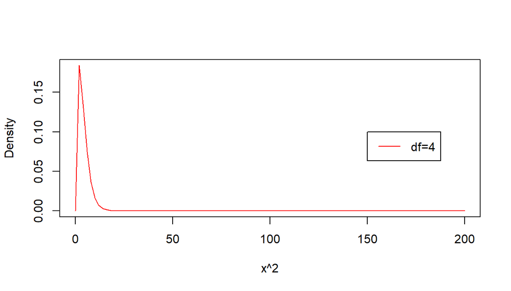

```r
curve(dchisq(x,4),col="red", to = 200, xlab = "x^2", ylab = "Density")
legend(150,0.1,c("df=4"),col=c("red"), lty=1)
```

As we see the chi square distribution plot of df = 4, the shaded area above 196.88 is almost zero.

```r
pchisq(q = 196.88, df = 4, lower.tail = FALSE)
```

```
## [1] 1.760404e-41
```

And calculated p-value is also almost zero and much less than significance level $\alpha$ = 0.05. Therefore, the null hypothesis is rejected. That is, the data provide convincing evidence that there is association between opinions on supporting government action to help poor people and the income class. Chi-square test for two-way tables does not create confidence interval.

## Summary

We’ve got through some steps composed of examining the properties of collected data, EDA and inferences to research into our research interest. And this anlaysis lead us to two conclusions. First, there is a significant difference in the proportions of US people only supporting government action between lower class and upper class. In other words, there is convincing evidence that the proportion of US people in low income class who think government should do action and have responsibilites to improve the living standard of poor people rather than they help themselves is more than that of those in upper income class. Secondly, there is a association between income level of US people and their opinions on appropriateness of government’s action to help US people in poverty. Although these conclusions may be reasonable because almost all people wants to get help from others rather than give helps, our analysis made it assured by statistical evidence.